```r
options(OutDec = ".")  # Asegurar punto decimal en este chunk

# Establecer semilla aleatoria
#set.seed(sample(1:10000, 1))

# Aleatorización del contexto del problema con concordancia de género
contextos_data <- data.frame(
  nombre = c("ciudad", "localidad", "comunidad", "comarca", "provincia", "zona",
             "municipio", "distrito", "territorio", "sector", "barrio", "pueblo"),
  genero = c("f", "f", "f", "f", "f", "f",
             "m", "m", "m", "m", "m", "m"),
  articulo = c("una", "una", "una", "una", "una", "una",
               "un", "un", "un", "un", "un", "un"),
  stringsAsFactors = FALSE
)
contexto_seleccionado <- contextos_data[sample(nrow(contextos_data), 1), ]
contexto <- contexto_seleccionado$nombre
articulo_contexto <- contexto_seleccionado$articulo

# Aleatorización del tipo de competencia con concordancia de género
competencias_data <- data.frame(
  nombre = c("carrera", "competencia atlética", "olimpiada deportiva",
             "justa deportiva", "prueba atlética", "competencia deportiva",
             "maratón", "torneo deportivo", "evento deportivo",
             "campeonato", "concurso deportivo", "certamen deportivo"),
  genero = c("f", "f", "f", "f", "f", "f",
             "m", "m", "m", "m", "m", "m"),
  articulo = c("una", "una", "una", "una", "una", "una",
               "un", "un", "un", "un", "un", "un"),
  stringsAsFactors = FALSE
)
competencia_seleccionada <- competencias_data[sample(nrow(competencias_data), 1), ]
competencia <- competencia_seleccionada$nombre
articulo_competencia <- competencia_seleccionada$articulo

# Aleatorización del grupo de edad
edades <- c(
  "menores de 15 años", "menores de 16 años", "menores de 14 años",
  "niños y niñas de 10 a 15 años", "jóvenes de 12 a 15 años",
  "estudiantes de primaria y secundaria", "categoría infantil",
  "categoría juvenil", "niños y adolescentes", "estudiantes menores de edad"
)
grupo_edad <- sample(edades, 1)

# Aleatorización del premio total (en millones)
premios_posibles <- c(30, 40, 50, 60, 70, 80, 90, 100, 120, 150) # Valores que facilitan cálculos con fracciones comunes
premio_total <- sample(premios_posibles, 1)

# Aleatorización de términos para el enunciado
terminos_premiar <- c("premiar", "recompensar", "reconocer", "galardonar", "incentivar")
termino_premiar <- sample(terminos_premiar, 1)

terminos_participantes <- c("participantes", "competidores", "concursantes", "deportistas")
termino_participantes <- sample(terminos_participantes, 1)

terminos_cuenta <- c("cuenta con", "dispone de", "tiene asignados", "ha destinado", "ha reservado")
termino_cuenta <- sample(terminos_cuenta, 1)

terminos_repartiran <- c("repartirán", "distribuirán", "dividirán", "asignarán", "otorgarán")
termino_repartiran <- sample(terminos_repartiran, 1)

terminos_puestos <- c("primeros puestos", "ganadores", "mejores lugares", "primeros lugares", "mejores posiciones")
termino_puestos <- sample(terminos_puestos, 1)

terminos_dinero <- c("dinero", "premio", "incentivo", "monto")
termino_dinero <- sample(terminos_dinero, 1)

# Aleatorización de fracciones para los puestos
# F1 para el primer puesto (del total), F2 para el segundo puesto (del restante)
# Asegurar que F1 < 1 y F2 < 1
conjuntos_fracciones <- list(
  c("1/2", "1/3"),  # Ej: 100 -> 1ro: 50, Rest: 50. 2do: 50*(1/3) ~ 17. 3ro: ~33
  c("1/3", "1/2"),  # Ej: 60 -> 1ro: 20, Rest: 40. 2do: 40*(1/2) = 20. 3ro: 20
  c("2/5", "1/4"),  # Ej: 100 -> 1ro: 40, Rest: 60. 2do: 60*(1/4) = 15. 3ro: 45
  c("3/5", "1/3"),  # Ej: 50 -> 1ro: 30, Rest: 20. 2do: 20*(1/3) ~ 7. 3ro: ~13
  c("1/4", "2/3"),  # Ej: 80 -> 1ro: 20, Rest: 60. 2do: 60*(2/3) = 40. 3ro: 20
  c("3/4", "1/5"),  # Ej: 100 -> 1ro: 75, Rest: 25. 2do: 25*(1/5) = 5. 3ro: 20
  c("2/3", "3/4"),  # Ej: 90 -> 1ro: 60, Rest: 30. 2do: 30*(3/4) = 22.5. 3ro: 7.5
  c("1/2", "2/5")
)
indice_conjunto <- sample(1:length(conjuntos_fracciones), 1)
fracciones_seleccionadas <- conjuntos_fracciones[[indice_conjunto]]

fraccion_primer_puesto_str <- fracciones_seleccionadas[1]
fraccion_segundo_puesto_str <- fracciones_seleccionadas[2] # Fracción del restante

# Convertir fracciones a valores numéricos para cálculos
convertir_fraccion <- function(fraccion) {
  partes <- strsplit(fraccion, "/")[[1]]
  return(as.numeric(partes[1]) / as.numeric(partes[2]))
}

valor_f1 <- convertir_fraccion(fraccion_primer_puesto_str) # Fracción del total para el 1er puesto
valor_f2 <- convertir_fraccion(fraccion_segundo_puesto_str) # Fracción del restante para el 2do puesto

# Calcular los montos para cada puesto según la nueva lógica
# Monto para el primer puesto
monto_primer_puesto_exacto <- premio_total * valor_f1
monto_primer_puesto <- round(monto_primer_puesto_exacto)

# Dinero restante después de asignar el primer puesto
restante_despues_primero <- premio_total - monto_primer_puesto

# Monto para el segundo puesto (del dinero restante)
monto_segundo_puesto_exacto <- restante_despues_primero * valor_f2
monto_segundo_puesto <- round(monto_segundo_puesto_exacto)

# Monto para el tercer puesto (el resto del dinero restante después del segundo)
# O, para asegurar que la suma total sea premio_total después de redondeos:
monto_tercer_puesto <- premio_total - (monto_primer_puesto + monto_segundo_puesto)

# Test para asegurar que el tercer puesto no sea negativo (debido a redondeos extremos)
# Esto es más un sanity check; con fracciones < 1, debería ser positivo.
test_that("El monto del tercer puesto es no negativo", {
  expect_true(monto_tercer_puesto >= 0)
})
```

Test passed 🎉

```r
# Verificar que la suma de los tres montos sea igual al premio total
test_that("La suma de los tres montos es igual al premio total", {
  expect_equal(monto_primer_puesto + monto_segundo_puesto + monto_tercer_puesto, premio_total)
})
```

Test passed 🎉

```r
# Generar opciones de respuesta
respuesta_correcta <- monto_tercer_puesto

# Generar distractores plausibles
distractor1 <- round(premio_total * valor_f1 * valor_f2) # F1 * F2 del total (error común)
distractor2 <- round(premio_total * (1 - valor_f1 - valor_f2)) # Si se suman F1 y F2 como del total
if (distractor2 < 0) distractor2 <- round(premio_total * 0.1) # Evitar negativo
distractor3 <- round(restante_despues_primero * (1-valor_f2) * 0.5) # Mitad de lo que no fue para el 2do (del restante)

# Asegurarse de que todos los distractores son diferentes de la respuesta correcta y entre sí
opciones_base <- c(respuesta_correcta, distractor1, distractor2, distractor3)
# Si hay duplicados con la respuesta correcta o entre distractores, ajustar ligeramente
if (any(duplicated(opciones_base))) {
    if (distractor1 == respuesta_correcta || distractor1 == distractor2 || distractor1 == distractor3) distractor1 <- round(premio_total * 0.15)
    if (distractor2 == respuesta_correcta || distractor2 == distractor1 || distractor2 == distractor3) distractor2 <- round(premio_total * 0.25)
    if (distractor3 == respuesta_correcta || distractor3 == distractor1 || distractor3 == distractor2) distractor3 <- round(premio_total * 0.05)
}
# Re-check for uniqueness after adjustments
opciones_finales_temp <- unique(c(respuesta_correcta, distractor1, distractor2, distractor3))
# Fill up to 4 options if unique produced less (e.g. all distractors became same as correct)
additional_distractors_needed <- 4 - length(opciones_finales_temp)
if (additional_distractors_needed > 0) {
    current_values <- opciones_finales_temp
    for (i in 1:additional_distractors_needed) {
        new_distractor <- round(premio_total * (0.1 + i*0.03))
        while(new_distractor %in% current_values) {
            new_distractor <- new_distractor + 1
        }
        opciones_finales_temp <- c(opciones_finales_temp, new_distractor)
        current_values <- c(current_values, new_distractor)
    }
}
# Ensure exactly 4 options, taking the first 4 if more were generated by chance
opciones <- opciones_finales_temp[1:4]

# Si después de los ajustes, la respuesta correcta no está o hay menos de 4 opciones únicas,
# se recurre a una generación más simple de distractores para asegurar validez.
if (length(unique(opciones)) < 4 || !respuesta_correcta %in% opciones) {
  opciones <- c(respuesta_correcta,
                round(respuesta_correcta * 0.5) + 1,
                round(respuesta_correcta * 1.5) + 2,
                round(premio_total * 0.1) + 3)
  opciones <- unique(opciones)
  while(length(opciones) < 4) {
    opciones <- c(opciones, max(opciones) + sample(1:5,1))
  }
  opciones <- opciones[1:4] # Ensure 4 options
  if(!respuesta_correcta %in% opciones){ # Failsafe if correct answer was removed
      opciones[sample(1:4,1)] <- respuesta_correcta
  }
}

opciones_mezcladas <- sample(opciones)
indice_correcto <- which(opciones_mezcladas == respuesta_correcta)
solucion <- rep(0, 4)
solucion[indice_correcto] <- 1

# Aleatorización de colores para la tabla
paletas_colores <- list(
  c("#4285F4", "#EA4335", "#FBBC05", "#34A853"),
  c("#1F77B4", "#FF7F0E", "#2CA02C", "#D62728"),
  c("#003f5c", "#58508d", "#bc5090", "#ff6361"),
  c("#0073C2", "#EFC000", "#868686", "#CD534C"),
  c("#7F3C8D", "#11A579", "#3969AC", "#F2B701")
)
paleta_seleccionada <- sample(paletas_colores, 1)[[1]]
color_encabezado <- paleta_seleccionada[1]
color_primer_puesto <- paleta_seleccionada[2]
color_segundo_puesto <- paleta_seleccionada[3]
color_tercer_puesto <- paleta_seleccionada[4]
```

```r
# Crear código Python para generar la tabla usando matplotlib
codigo_python <- paste0('
import matplotlib
matplotlib.use("Agg")
import matplotlib.pyplot as plt
import matplotlib.patches as patches
from matplotlib.gridspec import GridSpec
import numpy as np

# Configurar colores
color_encabezado = "', color_encabezado, '"
color_primer_puesto = "', color_primer_puesto, '"
color_segundo_puesto = "', color_segundo_puesto, '"
color_tercer_puesto = "', color_tercer_puesto, '"

# Crear figura y configurar grid
fig = plt.figure(figsize=(8, 3.5)) # Ajustado para posible texto más largo
gs = GridSpec(4, 2, height_ratios=[1, 1, 1, 1], width_ratios=[3, 7])

# Encabezado
ax_header = plt.subplot(gs[0, :])
ax_header.set_facecolor(color_encabezado)
ax_header.text(0.5, 0.5, "Distribución del premio de ', premio_total, ' millones de pesos",
              ha="center", va="center", color="white", fontweight="bold", fontsize=11)
ax_header.set_xticks([])
ax_header.set_yticks([])
for spine in ax_header.spines.values(): spine.set_visible(True)

# Primera fila
ax_p1_label = plt.subplot(gs[1, 0])
ax_p1_label.set_facecolor(color_primer_puesto)
ax_p1_label.text(0.5, 0.5, "Primer puesto", ha="center", va="center", color="white", fontweight="bold", fontsize=10)
ax_p1_label.set_xticks([])
ax_p1_label.set_yticks([])
for spine in ax_p1_label.spines.values(): spine.set_visible(True)

ax_p1_value = plt.subplot(gs[1, 1])
ax_p1_value.set_facecolor("white")
ax_p1_value.text(0.5, 0.5, "', fraccion_primer_puesto_str, ' del ', termino_dinero, ' total",
                ha="center", va="center", color="black", fontsize=10)
ax_p1_value.set_xticks([])
ax_p1_value.set_yticks([])
for spine in ax_p1_value.spines.values(): spine.set_visible(True)

# Segunda fila
ax_p2_label = plt.subplot(gs[2, 0])
ax_p2_label.set_facecolor(color_segundo_puesto)
ax_p2_label.text(0.5, 0.5, "Segundo puesto", ha="center", va="center", color="white", fontweight="bold", fontsize=10)
ax_p2_label.set_xticks([])
ax_p2_label.set_yticks([])
for spine in ax_p2_label.spines.values(): spine.set_visible(True)

ax_p2_value = plt.subplot(gs[2, 1])
ax_p2_value.set_facecolor("white")
ax_p2_value.text(0.5, 0.5, "', fraccion_segundo_puesto_str, ' del ', termino_dinero, ' restante tras el 1er puesto",
                ha="center", va="center", color="black", fontsize=9) # Fontsize ajustado
ax_p2_value.set_xticks([])
ax_p2_value.set_yticks([])
for spine in ax_p2_value.spines.values(): spine.set_visible(True)

# Tercera fila
ax_p3_label = plt.subplot(gs[3, 0])
ax_p3_label.set_facecolor(color_tercer_puesto)
ax_p3_label.text(0.5, 0.5, "Tercer puesto", ha="center", va="center", color="white", fontweight="bold", fontsize=10)
ax_p3_label.set_xticks([])
ax_p3_label.set_yticks([])
for spine in ax_p3_label.spines.values(): spine.set_visible(True)

ax_p3_value = plt.subplot(gs[3, 1])
ax_p3_value.set_facecolor("white")
ax_p3_value.text(0.5, 0.5, "el ', termino_dinero, ' que queda al final",
                ha="center", va="center", color="black", fontsize=10)
ax_p3_value.set_xticks([])
ax_p3_value.set_yticks([])
for spine in ax_p3_value.spines.values(): spine.set_visible(True)

plt.tight_layout(pad=0.5)
plt.savefig("tabla_distribucion.png", dpi=150, bbox_inches="tight")
plt.savefig("tabla_distribucion.pdf", dpi=150, bbox_inches="tight")
plt.close()
')

# Ejecutar código Python para generar la figura
py_run_string(codigo_python)
```

# Question

En una comarca se realizará un certamen deportivo para categoría juvenil. Para galardonar a los deportistas, la comarca tiene asignados 60 millones de pesos. Este monto se dividirán entre los tres mejores posiciones de la siguiente manera:

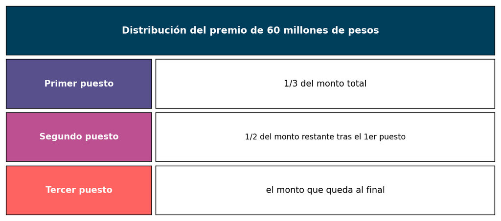

¿Qué cantidad de monto recibirá el tercer puesto?

## Answerlist

- 10 millones.
- 15 millones.
- 9 millones.
- 20 millones.

# Solution

Para resolver este problema, debemos calcular secuencialmente la cantidad de monto asignada a cada puesto.

### Paso 1: Identificar los datos del problema

- Premio total: 60 millones de pesos.
- Fracción para el primer puesto (del total): 1/3 (que es 0.3333333).
- Fracción para el segundo puesto (del restante): 1/2 (que es 0.5).
- El tercer puesto recibe lo que queda al final.

### Paso 2: Calcular el monto para el primer puesto

Multiplicamos la fracción del primer puesto por el premio total:

Monto del primer puesto = 60 millones × 1/3.

Monto del primer puesto = 60 × 0.3333333 = 20 millones.

Después de redondear (si es necesario), el primer puesto recibe: 20 millones.

### Paso 3: Calcular el dinero restante después del primer puesto

Restamos el monto del primer puesto del premio total:

Dinero restante = 60 millones - 20 millones.

Dinero restante = 40 millones. Este es el monto disponible para el segundo y tercer puesto.

### Paso 4: Calcular el monto para el segundo puesto

Multiplicamos la fracción del segundo puesto por el dinero restante calculado en el paso anterior:

Monto del segundo puesto = 40 millones × 1/2.

Monto del segundo puesto = 40 × 0.5 = 20 millones.

Después de redondear (si es necesario), el segundo puesto recibe: 20 millones.

### Paso 5: Calcular el monto para el tercer puesto

El tercer puesto recibe el monto que queda después de asignar los premios al primer y segundo puesto. Esto se puede calcular restando el monto del segundo puesto del dinero que quedaba después del primer puesto:

Monto del tercer puesto = Dinero restante después del primer puesto - Monto del segundo puesto.

Monto del tercer puesto = 40 millones - 20 millones.

Monto del tercer puesto = 20 millones.

Alternativamente, y para asegurar que la suma total sea correcta después de los redondeos:

Monto del tercer puesto = Premio total - (Monto del primer puesto + Monto del segundo puesto).

Monto del tercer puesto = 60 - (20 + 20).

Monto del tercer puesto = 60 - 40.

Monto del tercer puesto = 20 millones.

### Verificación

Comprobemos que la suma de los tres montos es igual al premio total:

- Primer puesto: 20 millones
- Segundo puesto: 20 millones
- Tercer puesto: 20 millones
- Total: 20 + 20 + 20 = 60 millones.

Esto coincide con el premio total de 60 millones.

Por lo tanto, el tercer puesto recibe 20 millones de pesos.

## Answerlist

- Falso
- Falso
- Falso
- Verdadero

# Meta-information

exname: fracciones_reparto_premio_v2 extype: schoice exsolution: 0001 exshuffle: TRUE exsection: Aritmética|Fracciones|Reparto proporcional|Secuencial